# Unsupervised learning - clustering and dimension reduction

David Coit

Fall 2019

## Homework

```r
data(iris)
```

0. Subset the Iris dataset to only include `Sepal.Length`, `Sepal.Width`, `Petal.Length`, and `Petal.Width`.

```r
# Subset iris to only include the variables listed above:
iris <- select(iris, "Sepal.Length", "Sepal.Width", "Petal.Length", "Petal.Width")
```

1. Write out the Kmeans algorithm by hand, and run two iterations of it.

**Algorithm summary:** **The first step in the k-means algorithm is to randomly assign each data point a number between 1 and k. We then calculate the k centroids of each group - ie the mean position of each point. Finally, we re-assign each data point a new value between 1 and k according to which cluster centroid is closest. We repeat the cluster centroid calculation and data point cluster reassignment until no data point changes cluster.** **Below, two iterations of the “hand written” k-means algorithm are run using k = 3. A table summarizing the number of datapoints in each cluster is displayed for each iteration, showing that the algorithm is working to reassign data points as it runs**

```r
# import library flexclust
# to easily compute distances between values in two matrices
library(flexclust)
```

```r
# Set the value of k
k <- 3

# Set number of iterations to run
iterations <- 2

# Initialize cluster assignment, assign each observation a random value 1:k
iris$cluster <- sample(k, nrow(iris), replace=T)

# Run two iterations of k-means algorithm
for(i in 1:iterations){
  # Calculate centroid coordinates per cluster
  centroids <- aggregate(. ~ cluster,
                        iris,
                        mean)
  # Calculate squared Euclidean distance between iris points and each cluster centroid
  centroid_dist <- dist2(iris[1:4], centroids[2:5], method="euc")*2
  # Reassign clusters per closest cluster centroid
  iris$cluster <- apply(centroid_dist, 1, which.min)
  # Printing count of cluster members to show algorithm progression
  print(table(iris$cluster))
}
```

```
##
##  1  2  3
## 29 30 91
##
##  1  2  3
## 33 21 96
```

2. Run PCA on the Iris dataset. Plot a scatter plot of PC1 vs PC2 and include the percent variance those PCs describe.

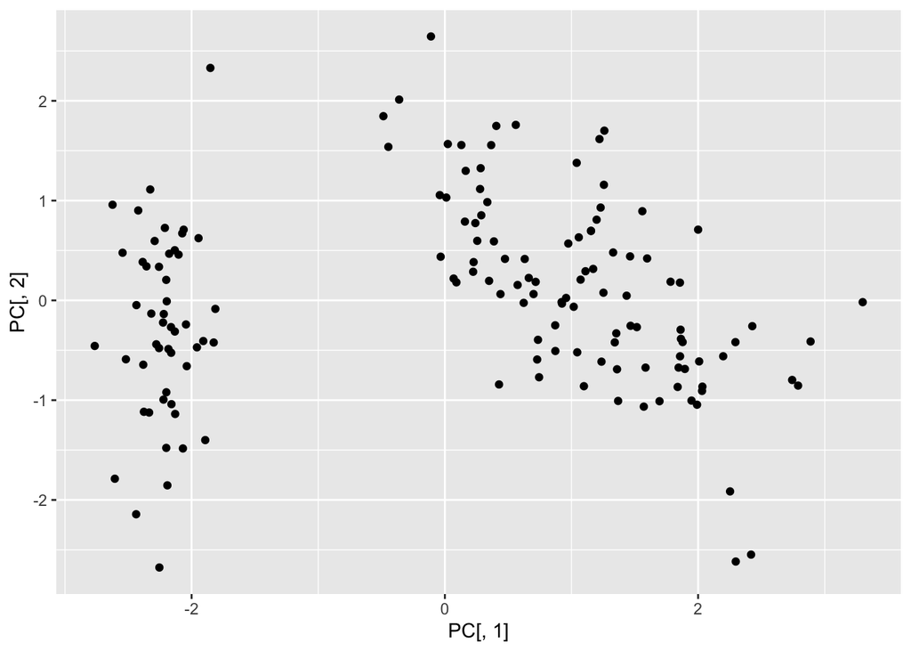

```r
# Reset iris data
data(iris)

# Compute PCA manually
# Normalize iris values
iris_centered <- apply(iris[,1:4],
                       2,
                       function(x) (x - mean(x)) / sd(x)
                       )
# Calculate covariance matrix
iris_cov <- cov(iris_centered)
# Calculate eigenvalues and eigenvectors
iris_eigenval <- eigen(iris_cov)$value
iris_eigenvec <- eigen(iris_cov)$vector

# Multiply original data by eigenvectors
PC <- as.data.frame(data.matrix(iris_centered) %*% iris_eigenvec)

# Find the percentage of variance explained by each principal component
# by computing culmulative eigenvalue
perc_var_explain <- round(cumsum(iris_eigenval)/sum(iris_eigenval) * 100, digits = 2)

# Plot principal components
ggplot(PC, aes(PC[,1], PC[,2])) + geom_point(aes(PC[,1], PC[,2]))
```

```r
# Print a string explaining how much variance each PC explains (cumulative)
result_string = paste0("Principal components 1 and 2 cumulatively explain ",
                       perc_var_explain[1],
                       "% and ",
                       perc_var_explain[2],
                       "% of the variance of the data respectively.")
print(result_string)
```

```
## [1] "Principal components 1 and 2 cumulatively explain 72.96% and 95.81% of the variance of the data respectively."
```

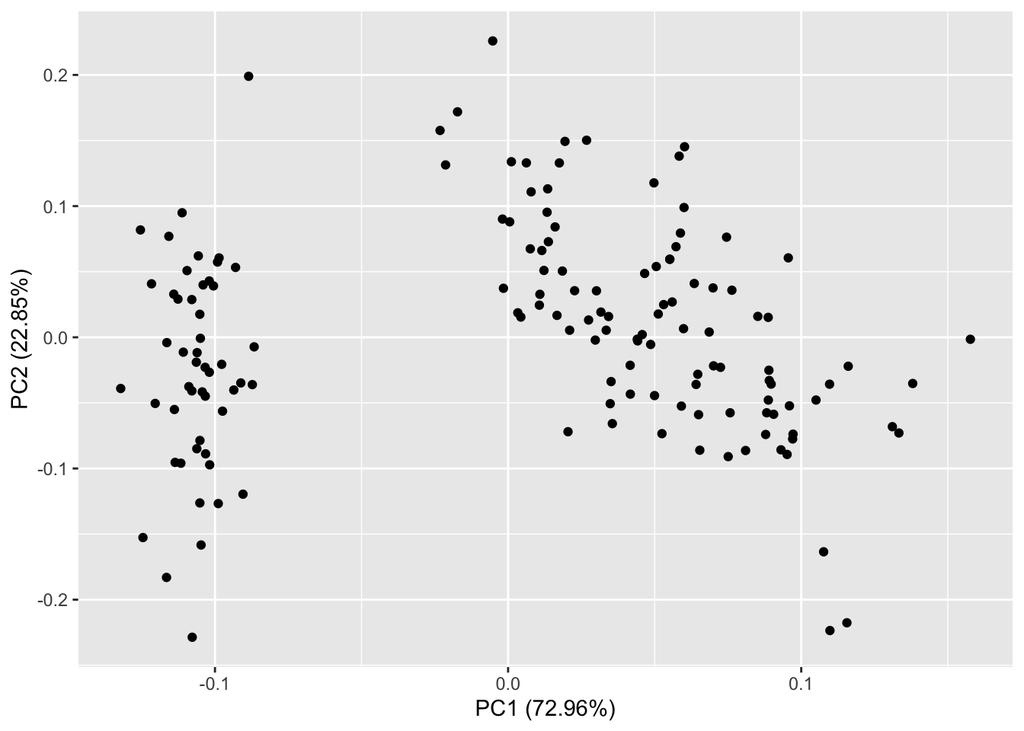

```r
# Same PCA plot using R's built-in functionality
# Normalize iris subset with center= and scale= arguments
# to check agreement with above procedure
autoplot(prcomp(data.matrix(iris_centered),
                center = TRUE,
                scale = TRUE))
```

3. Run ICA on the Iris dataset. Plot the independent components as a heatmap.

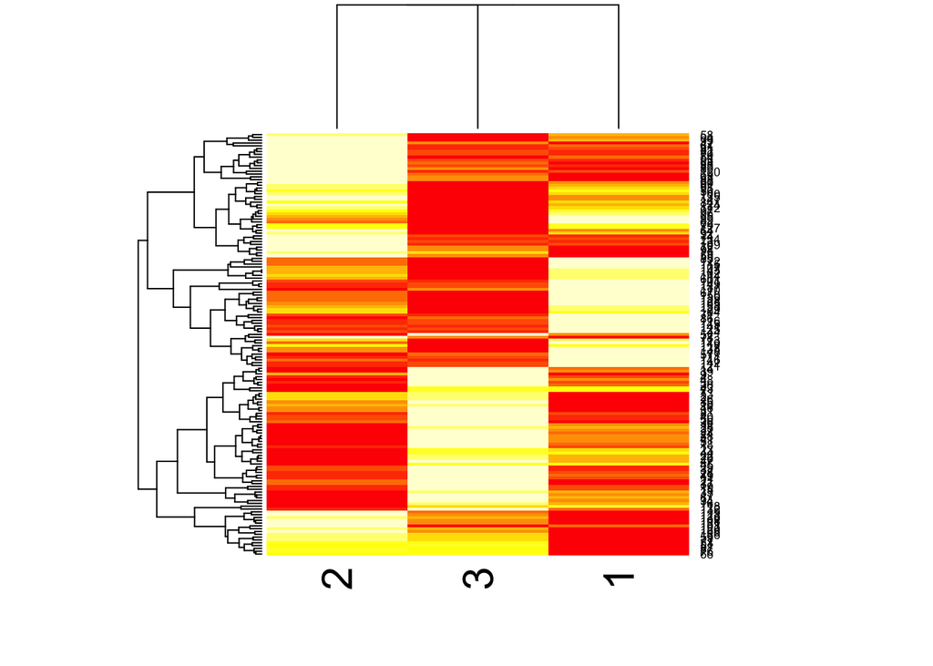

```r
# Plot 3 independent components of iris dataset
iris_ica <- fastICA(iris[,1:4], 3, alg.typ = "parallel", fun = "logcosh", alpha = 1,
             method = "R", row.norm = FALSE, maxit = 200,
             tol = 0.0001, verbose = TRUE)

heatmap(iris_ica$S)
```

**I chose to plot 3 independent components because there were measurements from 3 species of iris.**

4. Use Kmeans to cluster the Iris data.
- Use the silhouette function in the cluster package to find the optimal number of clusters for kmeans for the iris dataset. Then cluster using kmeans clustering. Does the data cluster by species?
  - Using this clustering, color the PCA plot according to the clusters.

```r
# load cluster package for kmeans() function
library(cluster)

# Reset iris_centered variable
rm(iris_centered)
iris_centered <- as.data.frame(apply(iris[,1:4],
                       2,
                       function(x) (x - mean(x)) / sd(x)
                       ))
# Calculate distance matrix
iris_dist <- as.matrix(dist(iris_centered, method = "euclidean"))

# Create a list of the number of clusters to test silhouette analysis on
# Create an empty vector to store mean silhouette widths
nclusters = c(2:10)
sil_width_list <- c()

# Iterate silhouette analysis over number of clusters
# Print results and store mean silhouette widths
for (k in nclusters){
  a <- kmeans(iris_centered, k)
  b <- silhouette(a[["cluster"]], iris_dist)
  mean_sil_width = round(mean(b[,3]), 3)
  print(paste0("The average silhouette width with ",
               k,
               " clusters is ",
               mean_sil_width
               )
        )
  sil_width_list <- c(sil_width_list, mean_sil_width)
  }
```

```
## [1] "The average silhouette width with 2 clusters is 0.582"
## [1] "The average silhouette width with 3 clusters is 0.46"
## [1] "The average silhouette width with 4 clusters is 0.419"
## [1] "The average silhouette width with 5 clusters is 0.384"
## [1] "The average silhouette width with 6 clusters is 0.377"
## [1] "The average silhouette width with 7 clusters is 0.363"
## [1] "The average silhouette width with 8 clusters is 0.304"
## [1] "The average silhouette width with 9 clusters is 0.339"
## [1] "The average silhouette width with 10 clusters is 0.314"
```

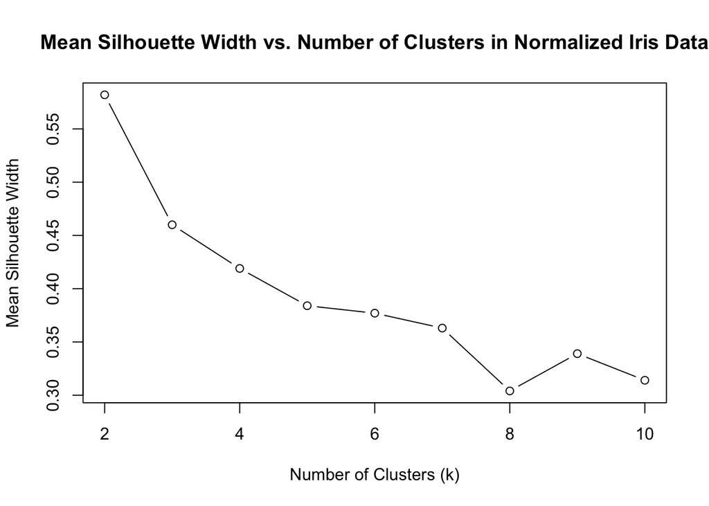

```r
# Plot results of silhouette analysis
plot(nclusters, sil_width_list,
     type = "b",
     xlab = "Number of Clusters (k)",
     ylab = "Mean Silhouette Width")
title("Mean Silhouette Width vs. Number of Clusters in Normalized Iris Data")
```

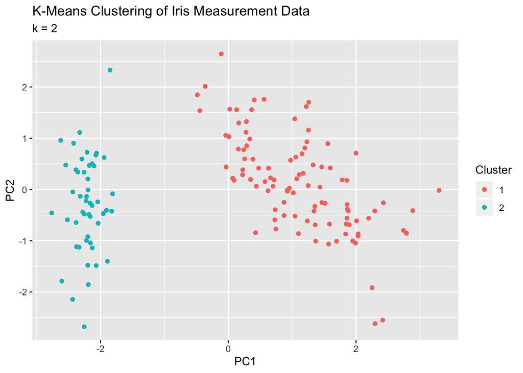

```r
# Perform k-means clustering
iris_cluster <- kmeans(iris_centered, 2)

# Perform PCA on normalized iris data
iris_PC <- prcomp(data.matrix(iris_centered[,1:4]),
                 center = TRUE,
                 scale = TRUE)

# Plot k-means clustering, color by cluster
ggplot(iris_PC,
       aes(x = PC1, y = PC2,
           color = as.factor(iris_cluster$cluster))) +
  geom_point() +
  labs(title = "K-Means Clustering of Iris Measurement Data",
       subtitle = "k = 2",
       color = "Cluster")
```

**Using the mean silhouette width as our metric, we can see that the optimal number of clusters to choose is 2. Because there are more species than there are clusters, this clustering cannot correctly separate all species present in the dataset, but it does correctly separate out the measurements of the setosa species from versicolor and virginica.**

**If we increase the number of clusters to three we still do not correctly separate versicolor and virginica:**

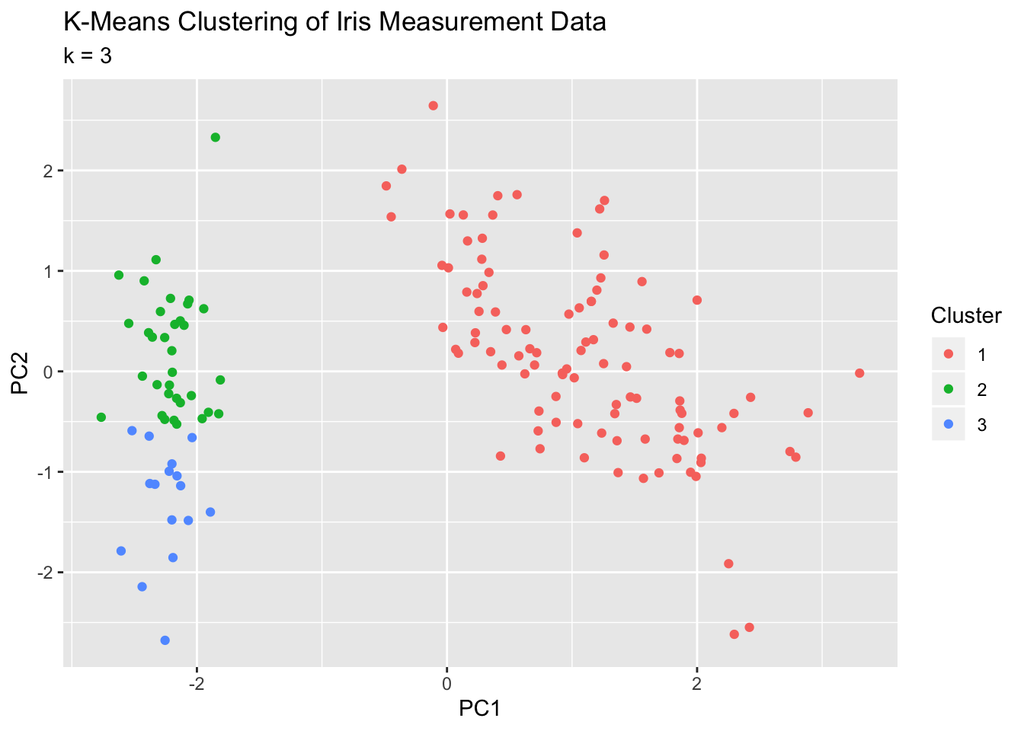

```r
# Perform k-means clustering
iris_cluster <- kmeans(iris_centered, 3)

# Perform PCA on normalized iris data
iris_PC <- prcomp(data.matrix(iris_centered[,1:4]),
                 center = TRUE,
                 scale = TRUE)

# Plot k-means clustering, color by cluster
ggplot(iris_PC,
       aes(x = PC1, y = PC2,
           color = as.factor(iris_cluster$cluster))) +
  geom_point() +
  labs(title = "K-Means Clustering of Iris Measurement Data",
       subtitle = "k = 3",
       color = "Cluster")
```

5. Use hierarchical clustering to cluster the Iris data.
- Try two different linkage types, and two different distance metrics.
- For one linkage type and one distance metric, try two different cut points.
- Using this clustering, color the PCA plot according to the clusters. (6 plots in total)

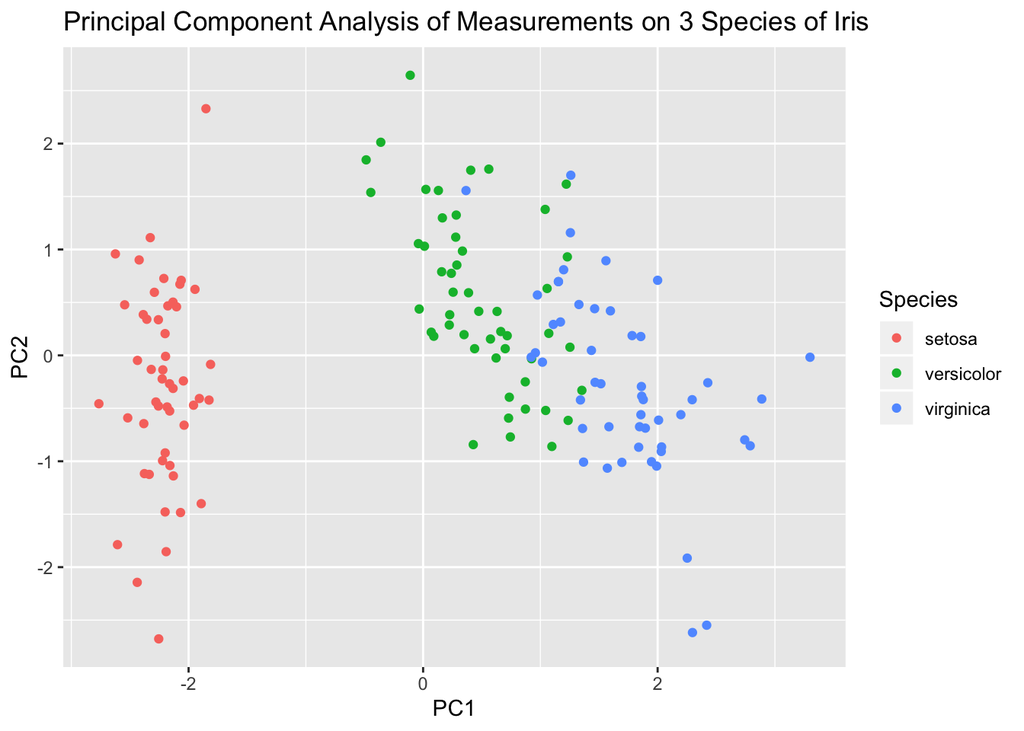

```r
# reset iris / iris_centered
# to include species data for cluster comparison
rm(iris)
rm(iris_centered)
data(iris)

iris_centered <- as.data.frame(apply(iris[,1:4],
                       2,
                       function(x) (x - mean(x)) / sd(x)
                       ))


# Clusters labeled with "1" will be computed with euclidean distance
# Clusters labeled with "2" will be computed with manhattan distance
# Clusters labeled with "a" will be computed by centroid linkage
# Clusters labeled with "b" will be computed by single linkage

# Compute one hierarchical clustering with centroid linkage
tree1a <- hclust(dist(iris_centered,
                      method="euclidean"),
                   method = "centroid")

tree1b <- hclust(dist(iris_centered,
                      method="euclidean"),
                   method = "single")

tree2a <- hclust(dist(iris_centered,
                      method="manhattan"),
                   method = "centroid")

tree2b <- hclust(dist(iris_centered,
                      method="manhattan"),
                   method = "single")


# Cut trees into three clusters
cluster1a <- cutree(tree1a, 3)
cluster1b <- cutree(tree1b, 3)
cluster2a <- cutree(tree2a, 3)
cluster2b <- cutree(tree2b, 3)
# Cut tree 1a and 2b into four clusters
cluster1a_4cut <- cutree(tree1a, 4)
cluster2b_4cut <- cutree(tree2b, 4)

# Bind cluster assignments to dataframe, add species back in
iris_centered <- cbind(iris_centered,
                       cluster1a,
                       cluster1b,
                       cluster2a,
                       cluster2b,
                       cluster1a_4cut,
                       cluster2b_4cut,
                       iris[,5])
colnames(iris_centered)[ncol(iris_centered)] <- "Species"

# Perform PCA on normalized iris data
iris_PC <- prcomp(data.matrix(iris_centered[,1:4]),
                 center = TRUE,
                 scale = TRUE)

# Plot species as a reference
ggplot(iris_PC,
       aes(x = PC1, y = PC2,
           color = as.character(iris_centered$Species))) +
  geom_point() +
  labs(title = "Principal Component Analysis of Measurements on 3 Species of Iris",
       color = "Species")
```

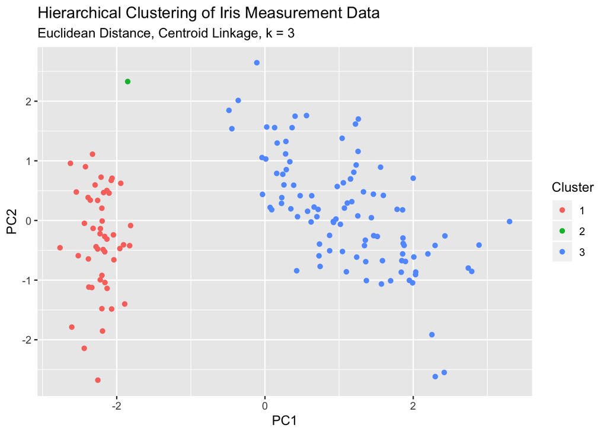

```r
# Plot clustering 1a
ggplot(iris_PC,
       aes(x = PC1, y = PC2,
           color = as.character(iris_centered$cluster1a))) +
  geom_point() +
  labs(title = "Hierarchical Clustering of Iris Measurement Data",
       subtitle = "Euclidean Distance, Centroid Linkage, k = 3",
       color = "Cluster")
```

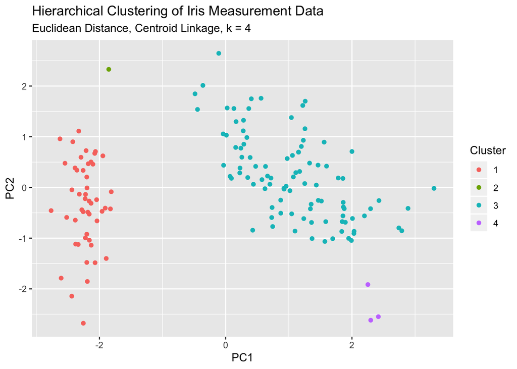

```r
# Plot clustering 1a with 4 cuts
ggplot(iris_PC,
       aes(x = PC1, y = PC2,
           color = as.character(iris_centered$cluster1a_4cut))) +
  geom_point() +
  labs(title = "Hierarchical Clustering of Iris Measurement Data",
       subtitle = "Euclidean Distance, Centroid Linkage, k = 4",
       color = "Cluster")
```

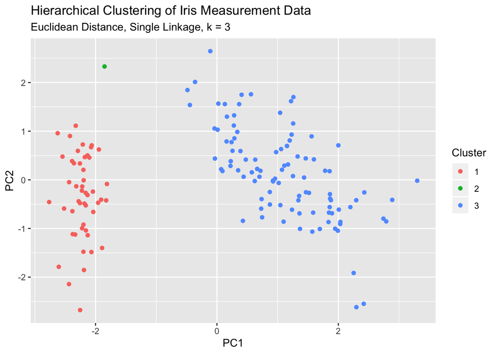

```r
# Plot clustering 1b
ggplot(iris_PC,
       aes(x = PC1, y = PC2,
           color = as.character(iris_centered$cluster1b))) +
  geom_point() +
  labs(title = "Hierarchical Clustering of Iris Measurement Data",
       subtitle = "Euclidean Distance, Single Linkage, k = 3",
       color = "Cluster")
```

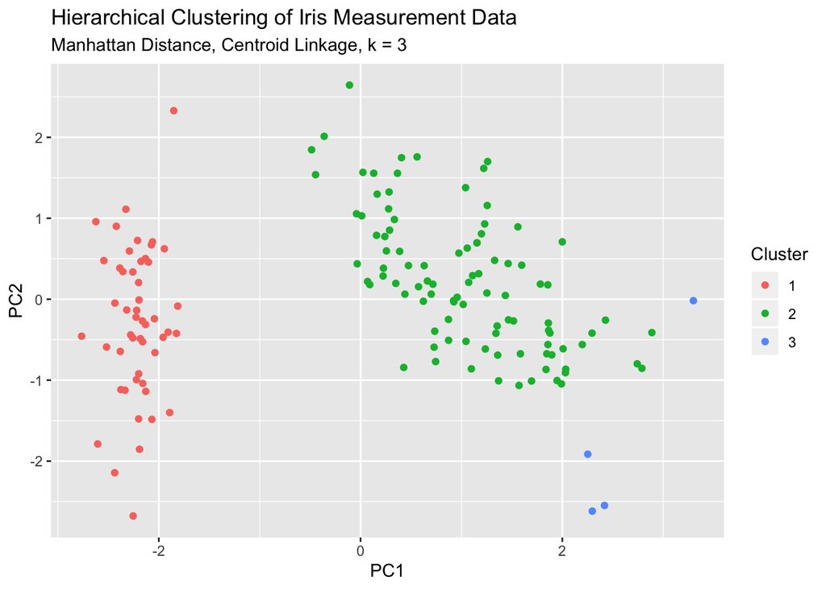

```r
# Plot clustering 2a
ggplot(iris_PC,
       aes(x = PC1, y = PC2,
           color = as.character(iris_centered$cluster2a))) +
  geom_point() +
    labs(title = "Hierarchical Clustering of Iris Measurement Data",
       subtitle = "Manhattan Distance, Centroid Linkage, k = 3",
       color = "Cluster")
```

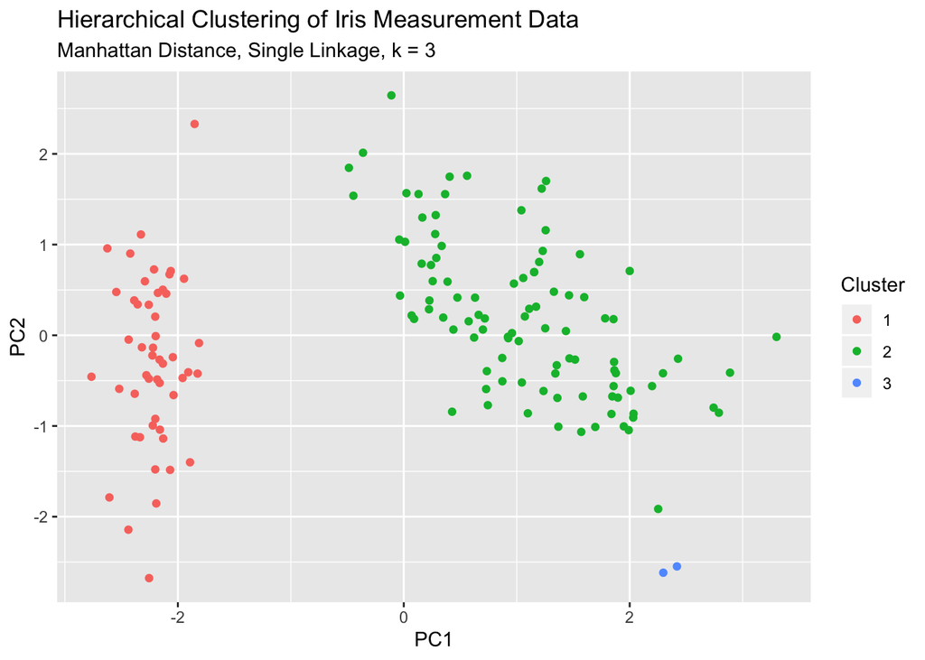

```r
# Plot clustering 2b
ggplot(iris_PC,
       aes(x = PC1, y = PC2,
           color = as.character(iris_centered$cluster2b))) +
  geom_point() +
    labs(title = "Hierarchical Clustering of Iris Measurement Data",
       subtitle = "Manhattan Distance, Single Linkage, k = 3",
       color = "Cluster")
```

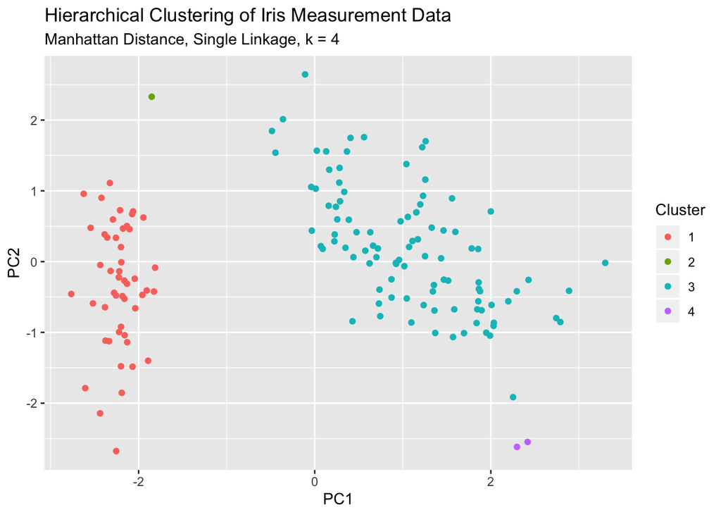

```r
# Plot clustering 2b with 4 cuts
ggplot(iris_PC,
       aes(x = PC1, y = PC2,
           color = as.character(iris_centered$cluster2b_4cut))) +
  geom_point() +
    labs(title = "Hierarchical Clustering of Iris Measurement Data",
       subtitle = "Manhattan Distance, Single Linkage, k = 4",
       color = "Cluster")
```

**One thing I found interesting about the applicatons of these clustering algorithms is that none of the correctly segregated the different species into their own clusters. Most were successful at clustering the all setosa plants save one together. Regardless of what distance measure was used, which linkage type was chosen, or the number of clusters assigned, the majority of versicolor and virginica data points were grouped together, with the “extra” clusters being composed of 1-4 outliers.**